# Project: Investigate a Dataset (No-show appointmentsa)

This dataset collects information rom 100k medical appointments in Brazil and is focused on the question of whether or not patients show up for their appointment.

- problem:- What is the problem we are facing?
- Problem solving (by asking questions)
- Dataset & Required Libraries (numpy, pandas ...)
- Data Wrangling
- Exploratory Data Analysis
- Conclusions

## Problem

```
A person makes a doctor appointment, receives all the instructions and no-show.
```

## Questions

- The main question here, why the person no-show doctor appointment ?
- What factors are important for us to know in order to predict if a patient will show up for their scheduled appointment?
- What gender is the most No-Show?
- Is there a specific schedule date that is not suitable for many?
- What is the average age of those who No-Show?
- What is the age of the most Show-Up and least?
- What is the total number of people in each neighborhood?
- How many people No-Show in each neighborhood?
- Are these features(Handcap,Scholarship,Hipertension,Diabetes,Alcoholism,Handcap,SMS_received) correlation for no-show? Explain .

### Dataset & Required Librarie

```python
# import the necessary packages. (pandas,numpy,matplotlib,seaborn)
import numpy as np
import pandas as pd
import matplotlib.pyplot as plt
import seaborn as sns
from sklearn import preprocessing

%matplotlib inline
# Loding the dataset with pandas (noshowappointments.csv) :
df=pd.read_csv('noshowappointments.csv')
```

## Data Wrangling

### General Properties

Load data and print a few lines. Perform operations to inspect data

```python
# Show 5 rows at random:
df.sample(5)
```

|  | PatientId | AppointmentID | Gender | ScheduledDay | AppointmentDay | Age | Neighbourhood | Scholarship | Hipertension | Diabetes | Alcoholism | Handcap | SMS_received | No-show |
| --- | --- | --- | --- | --- | --- | --- | --- | --- | --- | --- | --- | --- | --- | --- |
| 73035 | 9.575146e+11 | 5716766 | F | 2016-05-19T07:11:55Z | 2016-05-24T00:00:00Z | 14 | INHANGUETÁ | 0 | 0 | 0 | 0 | 0 | 1 | No |
| 42993 | 7.984752e+11 | 5609642 | M | 2016-04-20T16:28:28Z | 2016-05-30T00:00:00Z | 10 | JABOUR | 0 | 0 | 0 | 0 | 0 | 1 | No |
| 100353 | 9.464814e+13 | 5758810 | M | 2016-06-01T11:12:34Z | 2016-06-01T00:00:00Z | 54 | CENTRO | 0 | 0 | 0 | 0 | 0 | 0 | Yes |
| 46189 | 8.121397e+13 | 5632581 | M | 2016-04-28T08:11:25Z | 2016-05-06T00:00:00Z | 48 | MÁRIO CYPRESTE | 0 | 0 | 0 | 0 | 0 | 1 | No |
| 65445 | 9.422535e+14 | 5715889 | F | 2016-05-18T15:22:01Z | 2016-05-18T00:00:00Z | 11 | JARDIM CAMBURI | 0 | 0 | 0 | 0 | 0 | 0 | No |

There are some columns with misspellings that we need to fix (Handicap,Hipertension)

```python
#rename the coulmns from Hipertension to Hypertension and from Handcap to Handicap and save changes in df
df.rename(columns={'Hipertension':'Hypertension','Handcap':'Handicap'},inplace=True)
```

look for instances of missing

```python
df.isnull().sum()
```

```
PatientId         0
AppointmentID     0
Gender            0
ScheduledDay      0
AppointmentDay    0
Age               0
Neighbourhood     0
Scholarship       0
Hypertension      0
Diabetes          0
Alcoholism        0
Handicap          0
SMS_received      0
No-show           0
dtype: int64
```

##### No data is missing

look for instances possibly errant data.

```python
# get an overview of what we are dealing with
df.info()
```

```
<class 'pandas.core.frame.DataFrame'>
RangeIndex: 110527 entries, 0 to 110526
Data columns (total 14 columns):
 #   Column          Non-Null Count   Dtype
---  ------          --------------   -----
 0   PatientId       110527 non-null  float64
 1   AppointmentID   110527 non-null  int64
 2   Gender          110527 non-null  object
 3   ScheduledDay    110527 non-null  object
 4   AppointmentDay  110527 non-null  object
 5   Age             110527 non-null  int64
 6   Neighbourhood   110527 non-null  object
 7   Scholarship     110527 non-null  int64
 8   Hypertension    110527 non-null  int64
 9   Diabetes        110527 non-null  int64
 10  Alcoholism      110527 non-null  int64
 11  Handicap        110527 non-null  int64
 12  SMS_received    110527 non-null  int64
 13  No-show         110527 non-null  object
dtypes: float64(1), int64(8), object(5)
memory usage: 11.8+ MB
```

##### (ScheduledDay & AppointmentDay) must converted to datetime , Dropping irrelevant columns: PatientId

```python
#Ensure that there is no duplicated
sum(df.duplicated())
```

```
0
```

#### There is no duplicate data

```python
df.describe()
```

|  | PatientId | AppointmentID | Age | Scholarship | Hypertension | Diabetes | Alcoholism | Handicap | SMS_received |
| --- | --- | --- | --- | --- | --- | --- | --- | --- | --- |
| count | 1.105270e+05 | 1.105270e+05 | 110527.000000 | 110527.000000 | 110527.000000 | 110527.000000 | 110527.000000 | 110527.000000 | 110527.000000 |
| mean | 1.474963e+14 | 5.675305e+06 | 37.088874 | 0.098266 | 0.197246 | 0.071865 | 0.030400 | 0.022248 | 0.321026 |
| std | 2.560949e+14 | 7.129575e+04 | 23.110205 | 0.297675 | 0.397921 | 0.258265 | 0.171686 | 0.161543 | 0.466873 |
| min | 3.921784e+04 | 5.030230e+06 | -1.000000 | 0.000000 | 0.000000 | 0.000000 | 0.000000 | 0.000000 | 0.000000 |
| 25% | 4.172614e+12 | 5.640286e+06 | 18.000000 | 0.000000 | 0.000000 | 0.000000 | 0.000000 | 0.000000 | 0.000000 |
| 50% | 3.173184e+13 | 5.680573e+06 | 37.000000 | 0.000000 | 0.000000 | 0.000000 | 0.000000 | 0.000000 | 0.000000 |
| 75% | 9.439172e+13 | 5.725524e+06 | 55.000000 | 0.000000 | 0.000000 | 0.000000 | 0.000000 | 0.000000 | 1.000000 |
| max | 9.999816e+14 | 5.790484e+06 | 115.000000 | 1.000000 | 1.000000 | 1.000000 | 1.000000 | 4.000000 | 1.000000 |

In the age field, there are people whose age is less than 0, which is also wrong. There are people who are over 100 years old and also something wrong.

### Data Cleaning

```python
df.nunique()
```

```
PatientId          62299
AppointmentID     110527
Gender                 2
ScheduledDay      103549
AppointmentDay        27
Age                  104
Neighbourhood         81
Scholarship            2
Hypertension           2
Diabetes               2
Alcoholism             2
Handicap               5
SMS_received           2
No-show                2
dtype: int64
```

```python
df.Handicap.unique()
```

```
array([0, 1, 2, 3, 4], dtype=int64)
```

Handicap should have only values 0 or 1

##### we will replace [2,3,4] by 1

```python
df['Handicap'].replace(to_replace =[2, 3,4], value =1,inplace=True)
df.Handicap.unique()
```

```
array([0, 1], dtype=int64)
```

#### now Handicap is 0 or 1

```python
# convert ScheduledDay from object to  datetime
df['ScheduledDay']=pd.to_datetime(df['ScheduledDay'])
# convert AppointmentDay from object to  datetime
df['AppointmentDay']=pd.to_datetime(df['AppointmentDay'])
# drop PatientId
df.drop('PatientId', axis=1 ,inplace=True)
df.info()
```

```
<class 'pandas.core.frame.DataFrame'>
RangeIndex: 110527 entries, 0 to 110526
Data columns (total 13 columns):
 #   Column          Non-Null Count   Dtype
---  ------          --------------   -----
 0   AppointmentID   110527 non-null  int64
 1   Gender          110527 non-null  object
 2   ScheduledDay    110527 non-null  datetime64[ns, UTC]
 3   AppointmentDay  110527 non-null  datetime64[ns, UTC]
 4   Age             110527 non-null  int64
 5   Neighbourhood   110527 non-null  object
 6   Scholarship     110527 non-null  int64
 7   Hypertension    110527 non-null  int64
 8   Diabetes        110527 non-null  int64
 9   Alcoholism      110527 non-null  int64
 10  Handicap        110527 non-null  int64
 11  SMS_received    110527 non-null  int64
 12  No-show         110527 non-null  object
dtypes: datetime64[ns, UTC](2), int64(8), object(3)
memory usage: 11.0+ MB
```

#### ScheduledDay and AppointmentDay is data type : datetime

Ensure that there is no duplicate

```python
#Remove incorrect data when entering the age field
df=df[(df['Age'] >= 0) & (df['Age'] <= 95)]
df['Age'].describe()
```

```
count    110480.000000
mean         37.063342
std          23.079712
min           0.000000
25%          18.000000
50%          37.000000
75%          55.000000
max          95.000000
Name: Age, dtype: float64
```

##### now the age field Prepared to work

Get label encoder mappings to see if there is a relationship between features and some of them

```python
#get mappings of a label encoder
le=preprocessing.LabelEncoder()
#get mappings of a label encoder Gender
df['Gender_labeling'] = le.fit_transform(df['Gender'])
#get mappings of a label encoder Neighbourhood
df['Neighbourhood_labeling'] = le.fit_transform(df['Neighbourhood'])
#get mappings of a label encoder No-show
df['No-show_labeling'] = le.fit_transform(df['No-show'])
df.describe()
```

|  | AppointmentID | Age | Scholarship | Hypertension | Diabetes | Alcoholism | Handicap | SMS_received | Gender_labeling | Neighbourhood_labeling | No-show_labeling |
| --- | --- | --- | --- | --- | --- | --- | --- | --- | --- | --- | --- |
| count | 1.104800e+05 | 110480.000000 | 110480.000000 | 110480.000000 | 110480.000000 | 110480.000000 | 110480.000000 | 110480.000000 | 110480.000000 | 110480.000000 | 110480.000000 |
| mean | 5.675303e+06 | 37.063342 | 0.098307 | 0.197076 | 0.071841 | 0.030413 | 0.020203 | 0.321126 | 0.350091 | 41.739518 | 0.201955 |
| std | 7.128285e+04 | 23.079712 | 0.297731 | 0.397792 | 0.258226 | 0.171721 | 0.140694 | 0.466911 | 0.477000 | 22.359735 | 0.401461 |
| min | 5.030230e+06 | 0.000000 | 0.000000 | 0.000000 | 0.000000 | 0.000000 | 0.000000 | 0.000000 | 0.000000 | 0.000000 | 0.000000 |
| 25% | 5.640284e+06 | 18.000000 | 0.000000 | 0.000000 | 0.000000 | 0.000000 | 0.000000 | 0.000000 | 0.000000 | 26.000000 | 0.000000 |
| 50% | 5.680564e+06 | 37.000000 | 0.000000 | 0.000000 | 0.000000 | 0.000000 | 0.000000 | 0.000000 | 0.000000 | 40.000000 | 0.000000 |
| 75% | 5.725507e+06 | 55.000000 | 0.000000 | 0.000000 | 0.000000 | 0.000000 | 0.000000 | 1.000000 | 1.000000 | 60.000000 | 0.000000 |
| max | 5.790484e+06 | 95.000000 | 1.000000 | 1.000000 | 1.000000 | 1.000000 | 1.000000 | 1.000000 | 1.000000 | 80.000000 | 1.000000 |

#### Now we make sure the data is clean, next step...

## Exploratory Data Analysis

#### To see if there is a clear relationship between the features and No-show

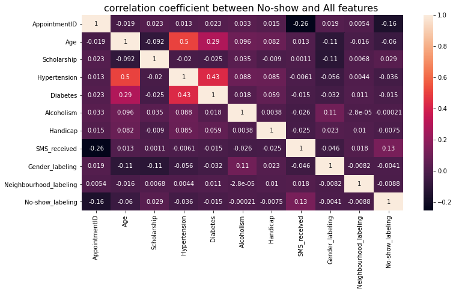

```python
f,ax=plt.subplots(1,1,figsize=(12,6))
sns.heatmap(df.corr(),annot=True)
ax.set_title('correlation coefficient between No-show and All features ',fontsize=16)
```

#### All relationships with no-show are weak

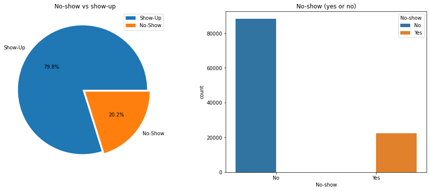

```python
total_Noshow=df['No-show'].value_counts()
total_Noshow.index=['Show-Up','No-Show']

f,ax=plt.subplots(1,2,figsize=(16,6))
total_Noshow.plot.pie(explode=[0.05,0],autopct='%1.1f%%',ax=ax[0])
ax[0].set_title('No-show vs show-up')
ax[0].set_ylabel('')
ax[0].legend()

sns.countplot(x='No-show',hue="No-show",data=df,ax=ax[1])
ax[1].set_title('No-show (yes or no)')
```

> **note**: We note that the show up (80%) rate is large, it is clear from the figure

### What gender is the most No-Show?

```python
df.groupby(['Gender','No-show']).size().unstack()
```

| No-show Gender | No | Yes |
| --- | --- | --- |
| F | 57214 | 14588 |
| M | 30954 | 7724 |

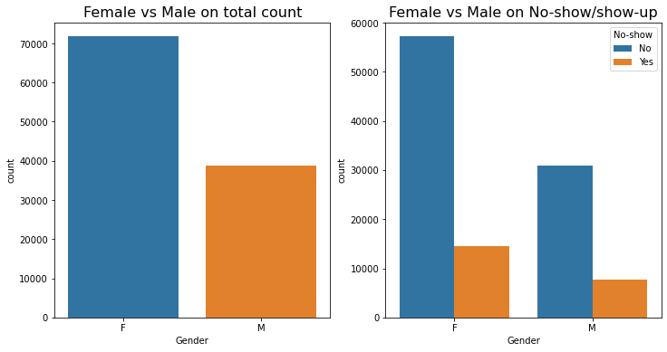

```python
f,ax=plt.subplots(1,2,figsize=(12,6))

sns.countplot(x='Gender',data=df,ax=ax[0])
ax[0].set_title('Female vs Male on total count',fontsize=16)
# Female vs Male on No-show
sns.countplot(x='Gender',hue="No-show",data=df,ax=ax[1])
ax[1].set_title('Female vs Male on No-show/show-up',fontsize=16)
```

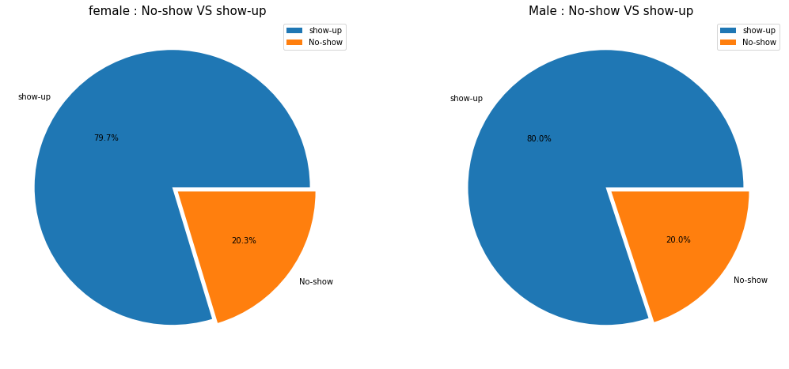

```python
f,ax=plt.subplots(1,2,figsize=(18,8))

female = df[df['Gender']=='F'].groupby(['No-show'])['No-show'].count()
female.index=['show-up','No-show']


male = df[df['Gender']=='M'].groupby(['No-show'])['No-show'].count()
male.index=['show-up','No-show']



female.plot.pie(explode=[0.05,0],autopct='%1.1f%%',ax=ax[0])
ax[0].set_title('female : No-show VS show-up',fontsize=15)
ax[0].set_ylabel('')
ax[0].legend()

male.plot.pie(explode=[0.05,0],autopct='%1.1f%%',ax=ax[1])
ax[1].set_title('Male : No-show VS show-up',fontsize=15)
ax[1].set_ylabel('')
ax[1].legend()
```

> **note**: It is clear that there is no specific gender that no-show its date (no-show is not related to gender),The no-show rate is almost equal

### Is there a specific schedule date that is not suitable for many?

```python
df['ScheduledDay_DateOnly']=df['ScheduledDay'].dt.date
df.groupby(['ScheduledDay_DateOnly','No-show']).size().unstack()
```

| No-show ScheduledDay_DateOnly | No | Yes |
| --- | --- | --- |
| 2015-11-10 | 1.0 | NaN |
| 2015-12-03 | NaN | 1.0 |
| 2015-12-07 | 8.0 | 2.0 |
| 2015-12-08 | 24.0 | 13.0 |
| 2015-12-14 | 5.0 | 1.0 |
| ... | ... | ... |
| 2016-06-03 | 2189.0 | 306.0 |
| 2016-06-04 | 1.0 | NaN |
| 2016-06-06 | 2203.0 | 197.0 |
| 2016-06-07 | 1663.0 | 115.0 |
| 2016-06-08 | 1469.0 | 68.0 |

111 rows × 2 columns

```python
df.groupby(['ScheduledDay_DateOnly','No-show']).size().unstack()['No'].sort_values(ascending=False).head(1)
```

```
ScheduledDay_DateOnly
2016-05-02    3417.0
Name: No, dtype: float64
```

```python
df.groupby(['ScheduledDay_DateOnly','No-show']).size().unstack()['Yes'].sort_values(ascending=False).head(1)
```

```
ScheduledDay_DateOnly
2016-05-03    893.0
Name: Yes, dtype: float64
```

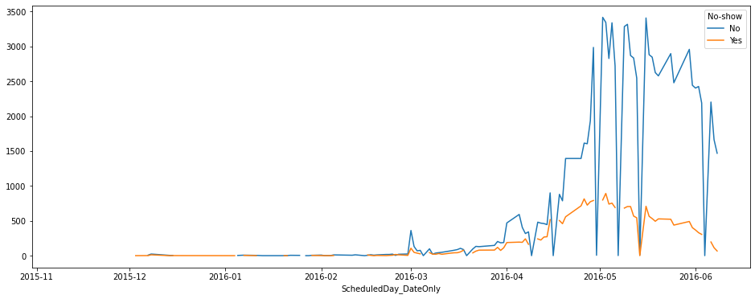

```python
f,ax=plt.subplots(1,1,figsize=(16,6))
df.groupby(['ScheduledDay_DateOnly','No-show']).size().unstack().plot(ax=ax)
```

> **note** : Starting in the fourth month, people flock to the doctors, make an appointment, and show up
> - The most No-show is: 2016-05-03, Count : 893.0
> - The most show up is: 2016-05-02, Count : 3417.0

### What is the average age of those who No-Show?

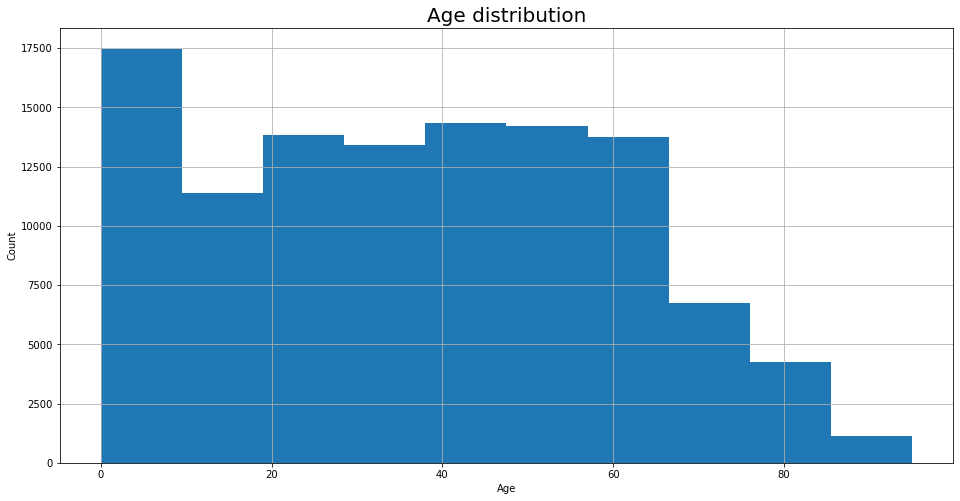

```python
f,ax=plt.subplots(1,1,figsize=(16,8))
df['Age'].hist()
ax.set_title('Age distribution',fontsize=20)
ax.set_xlabel('Age')
ax.set_ylabel('Count')
ax.grid=True
```

```python
print(df[df['No-show']=='Yes']['Age'].mean())
print(df[df['No-show']=='No']['Age'].mean())
```

```
34.295580853352455
37.763757825968604
```

> - the average age of those who No-Show : 34.295580853352455
> - the average age of those who Show up : 37.763757825968604

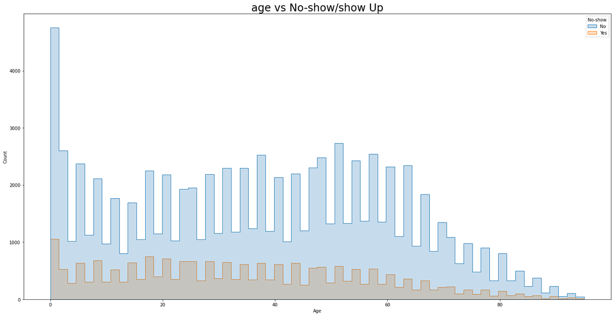

```python
f,ax=plt.subplots(1,1,figsize=(24,12))

sns.histplot(data=df, x="Age",hue='No-show', element="step",ax=ax)
ax.set_title('age vs No-show/show Up',fontsize=24)
```

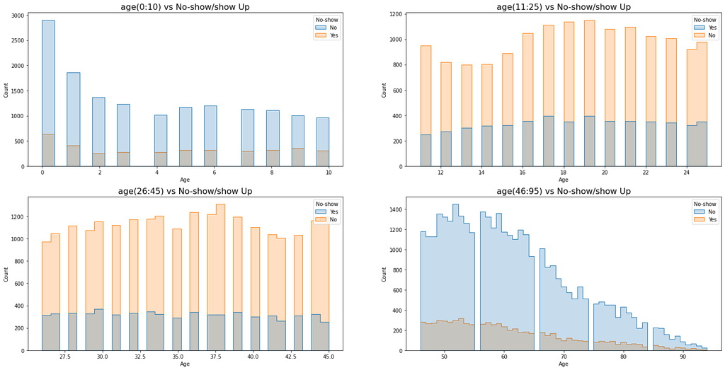

```python
f,ax=plt.subplots(2,2,figsize=(24,12))

sns.histplot(data=df[df['Age']<=10], x="Age",hue='No-show', element="step",ax=ax[0,0])
ax[0,0].set_title('age(0:10) vs No-show/show Up',fontsize=16)

sns.histplot(data=df[(df['Age']>10)&(df['Age']<=25)], x="Age",hue='No-show', element="step",ax=ax[0,1])
ax[0,1].set_title('age(11:25) vs No-show/show Up',fontsize=16)

sns.histplot(data=df[(df['Age']>25)&(df['Age']<=45)], x="Age",hue='No-show', element="step",ax=ax[1,0])
ax[1,0].set_title('age(26:45) vs No-show/show Up',fontsize=16)

sns.histplot(data=df[(df['Age']>45)&(df['Age']<95)], x="Age",hue='No-show', element="step",ax=ax[1,1])
ax[1,1].set_title('age(46:95) vs No-show/show Up',fontsize=16)
```

### The no-show rate is almost the same

### What is the total number of people in each neighborhood?

```
JARDIM CAMBURI                 7714
MARIA ORTIZ                    5804
RESISTÊNCIA                    4431
JARDIM DA PENHA                3874
ITARARÉ                        3514
                               ...
ILHA DO BOI                      35
ILHA DO FRADE                    10
AEROPORTO                         8
ILHAS OCEÂNICAS DE TRINDADE       2
PARQUE INDUSTRIAL                 1
Name: Neighbourhood, Length: 81, dtype: int64
```

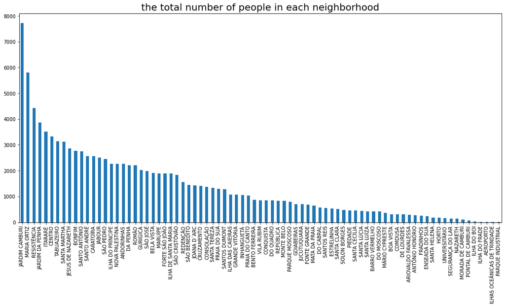

```python
f,ax=plt.subplots(1,1,figsize=(18,8))
df['Neighbourhood'].value_counts().plot(kind='bar',ax=ax)
ax.set_title("the total number of people in each neighborhood",fontsize=20)
df['Neighbourhood'].value_counts()
```

### How many people No-Show in each neighborhood?

```
JARDIM CAMBURI                 1465
MARIA ORTIZ                    1219
ITARARÉ                         923
RESISTÊNCIA                     906
CENTRO                          703
                               ...
PONTAL DE CAMBURI                12
ILHA DO BOI                       3
ILHAS OCEÂNICAS DE TRINDADE       2
ILHA DO FRADE                     2
AEROPORTO                         1
Name: Neighbourhood, Length: 80, dtype: int64
```

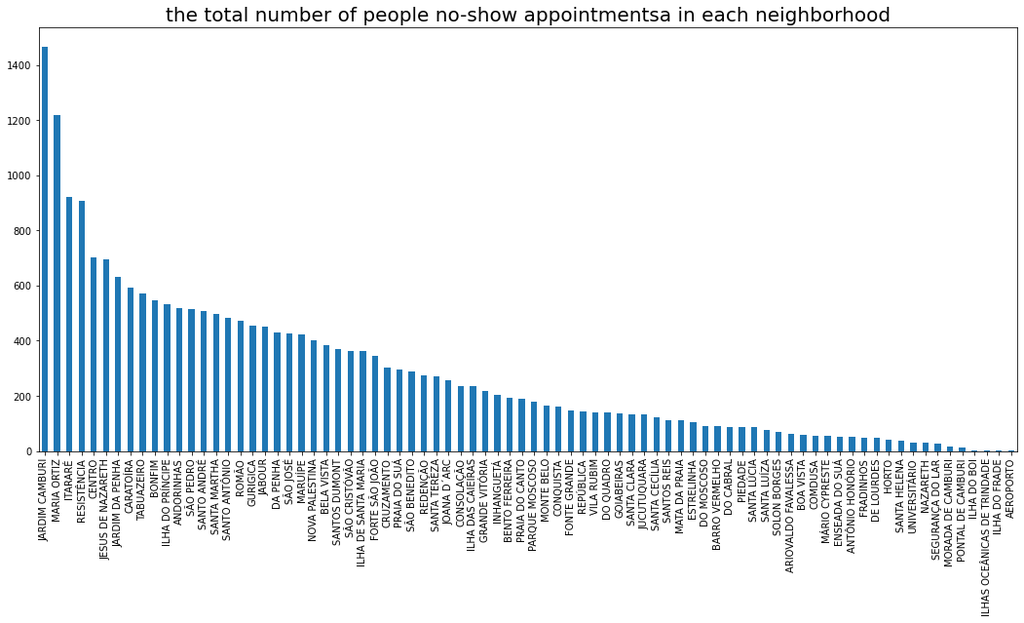

```python
f,ax=plt.subplots(1,1,figsize=(18,8))
df[df['No-show']=='Yes']['Neighbourhood'].value_counts().plot(kind='bar',ax=ax)
ax.set_title("the total number of people no-show appointmentsa in each neighborhood",fontsize=20)
df[df['No-show']=='Yes']['Neighbourhood'].value_counts()
```

### How many people Show up in each neighborhood?

```
JARDIM CAMBURI       6249
MARIA ORTIZ          4585
RESISTÊNCIA          3525
JARDIM DA PENHA      3243
SANTA MARTHA         2633
                     ...
PONTAL DE CAMBURI      57
ILHA DO BOI            32
ILHA DO FRADE           8
AEROPORTO               7
PARQUE INDUSTRIAL       1
Name: Neighbourhood, Length: 80, dtype: int64
```

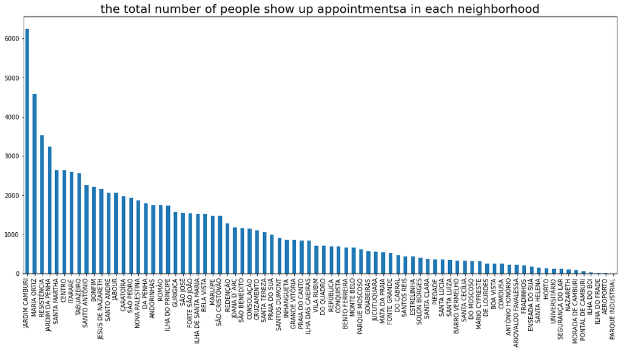

```python
f,ax=plt.subplots(1,1,figsize=(18,8))
df[df['No-show']=='No']['Neighbourhood'].value_counts().plot(kind='bar',ax=ax)
ax.set_title("the total number of people show up appointmentsa in each neighborhood",fontsize=20)
df[df['No-show']=='No']['Neighbourhood'].value_counts()
```

#### No-show and Show Up rate for each Neighbourhood, divide each count by the total count , use proportions

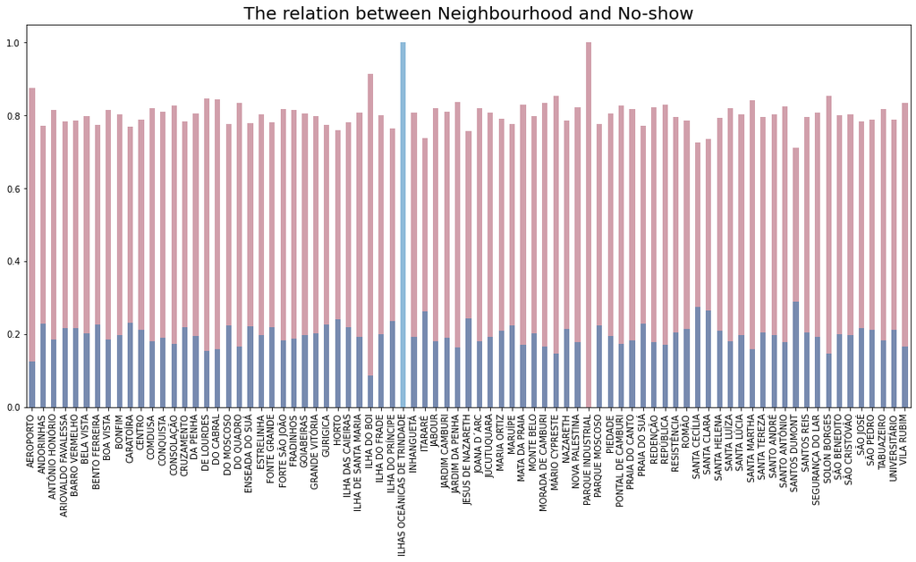

```python
f,ax=plt.subplots(1,1,figsize=(18,8))
showup=df[df['No-show']=='No']['Neighbourhood'].value_counts()/df['Neighbourhood'].value_counts()
noshow= df[df['No-show']=='Yes']['Neighbourhood'].value_counts()/df['Neighbourhood'].value_counts()
(showup).plot(kind='bar',ax=ax,alpha=.5,color='#A54158')
(noshow).plot(kind='bar',ax=ax,alpha=.5,)
ax.set_title('The relation between Neighbourhood and No-show',fontsize=20)
```

#### There is a related between No-show and the neighborhood

### Are these features(Handcap,Scholarship,Hipertension,Diabetes,Alcoholism,Handcap,SMS_received) correlation for no-show? Explain .

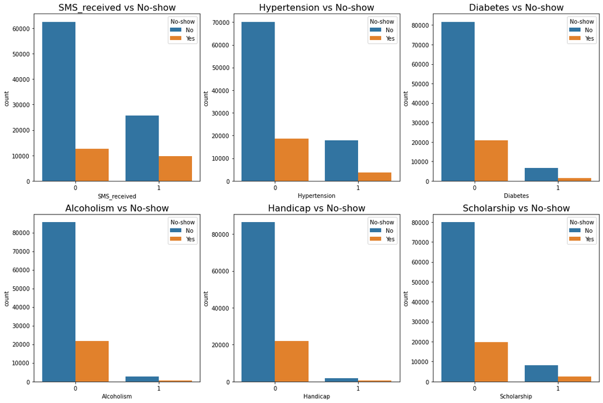

```python
f,ax=plt.subplots(2,3,figsize=(18,12))
sns.countplot(x='SMS_received', data=df, hue='No-show', ax=ax[0,0]);
ax[0,0].set_title('SMS_received vs No-show',fontsize=16)

sns.countplot(x='Hypertension', data=df, hue='No-show', ax=ax[0,1]);
ax[0,1].set_title('Hypertension vs No-show',fontsize=16)

sns.countplot(x='Diabetes', data=df, hue='No-show', ax=ax[0,2]);
ax[0,2].set_title('Diabetes vs No-show',fontsize=16)

sns.countplot(x='Alcoholism', data=df, hue='No-show', ax=ax[1,0]);
ax[1,0].set_title('Alcoholism vs No-show',fontsize=16)

sns.countplot(x='Handicap', data=df, hue='No-show', ax=ax[1,1]);
ax[1,1].set_title('Handicap vs No-show',fontsize=16)

sns.countplot(x='Scholarship', data=df, hue='No-show', ax=ax[1,2]);
ax[1,2].set_title('Scholarship vs No-show',fontsize=16)
```

> - no-show in SMS_received is higher than in SMS_unreceived.
> - hypertension is more common than diabetes in the patients
> - The data does not contain many alcoholics

## Conclusions

#### limitations:

> - There are values outside in the age field, since there is a person whose age is the youngest person, and people whose age is greater than 100
> - There is no clear relationship between no-show and a lot of features
> - In the "Handicap" field there are 0:4 values, but it should be 0 or 1